```r
library(RWeka)
library(RWekajars)
library(rJava)
library(partykit)
library(e1071)
library(formattable)
library(hash)
library(plyr)
```

**PART 1**

Reading data.

```r
sonar = read.csv("data/sonar.all-data", header=FALSE)
names(sonar)[names(sonar) == 'V61'] <- 'Class'

dim(sonar)
```

```
## [1] 208  61
```

```r
str(sonar)
```

```
## 'data.frame':    208 obs. of  61 variables:
##  $ V1   : num  0.02 0.0453 0.0262 0.01 0.0762 0.0286 0.0317 0.0519 0.0223 0.0164 ...
##  $ V2   : num  0.0371 0.0523 0.0582 0.0171 0.0666 0.0453 0.0956 0.0548 0.0375 0.0173 ...
##  $ V3   : num  0.0428 0.0843 0.1099 0.0623 0.0481 ...
##  $ V4   : num  0.0207 0.0689 0.1083 0.0205 0.0394 ...
##  $ V5   : num  0.0954 0.1183 0.0974 0.0205 0.059 ...
##  $ V6   : num  0.0986 0.2583 0.228 0.0368 0.0649 ...
##  $ V7   : num  0.154 0.216 0.243 0.11 0.121 ...
##  $ V8   : num  0.16 0.348 0.377 0.128 0.247 ...
##  $ V9   : num  0.3109 0.3337 0.5598 0.0598 0.3564 ...
##  $ V10  : num  0.211 0.287 0.619 0.126 0.446 ...
##  $ V11  : num  0.1609 0.4918 0.6333 0.0881 0.4152 ...
##  $ V12  : num  0.158 0.655 0.706 0.199 0.395 ...
##  $ V13  : num  0.2238 0.6919 0.5544 0.0184 0.4256 ...
##  $ V14  : num  0.0645 0.7797 0.532 0.2261 0.4135 ...
```

[output cut: 47 more lines]

```r
summary(sonar)
```

```
##        V1                V2                V3                V4
##  Min.   :0.00150   Min.   :0.00060   Min.   :0.00150   Min.   :0.00580
##  1st Qu.:0.01335   1st Qu.:0.01645   1st Qu.:0.01895   1st Qu.:0.02438
##  Median :0.02280   Median :0.03080   Median :0.03430   Median :0.04405
##  Mean   :0.02916   Mean   :0.03844   Mean   :0.04383   Mean   :0.05389
##  3rd Qu.:0.03555   3rd Qu.:0.04795   3rd Qu.:0.05795   3rd Qu.:0.06450
##  Max.   :0.13710   Max.   :0.23390   Max.   :0.30590   Max.   :0.42640
##        V5                V6                V7               V8
##  Min.   :0.00670   Min.   :0.01020   Min.   :0.0033   Min.   :0.00550
##  1st Qu.:0.03805   1st Qu.:0.06703   1st Qu.:0.0809   1st Qu.:0.08042
##  Median :0.06250   Median :0.09215   Median :0.1070   Median :0.11210
##  Mean   :0.07520   Mean   :0.10457   Mean   :0.1217   Mean   :0.13480
##  3rd Qu.:0.10028   3rd Qu.:0.13412   3rd Qu.:0.1540   3rd Qu.:0.16960
##  Max.   :0.40100   Max.   :0.38230   Max.   :0.3729   Max.   :0.45900
##        V9               V10              V11              V12
##  Min.   :0.00750   Min.   :0.0113   Min.   :0.0289   Min.   :0.0236
##  1st Qu.:0.09703   1st Qu.:0.1113   1st Qu.:0.1293   1st Qu.:0.1335
##  Median :0.15225   Median :0.1824   Median :0.2248   Median :0.2490
##  Mean   :0.17800   Mean   :0.2083   Mean   :0.2360   Mean   :0.2502
##  3rd Qu.:0.23342   3rd Qu.:0.2687   3rd Qu.:0.3016   3rd Qu.:0.3312
##  Max.   :0.68280   Max.   :0.7106   Max.   :0.7342   Max.   :0.7060
##       V13              V14              V15              V16
##  Min.   :0.0184   Min.   :0.0273   Min.   :0.0031   Min.   :0.0162
##  1st Qu.:0.1661   1st Qu.:0.1752   1st Qu.:0.1646   1st Qu.:0.1963
##  Median :0.2640   Median :0.2811   Median :0.2817   Median :0.3047
##  Mean   :0.2733   Mean   :0.2966   Mean   :0.3202   Mean   :0.3785
##  3rd Qu.:0.3513   3rd Qu.:0.3862   3rd Qu.:0.4529   3rd Qu.:0.5357
##  Max.   :0.7131   Max.   :0.9970   Max.   :1.0000   Max.   :0.9988
##       V17              V18              V19              V20
##  Min.   :0.0349   Min.   :0.0375   Min.   :0.0494   Min.   :0.0656
##  1st Qu.:0.2059   1st Qu.:0.2421   1st Qu.:0.2991   1st Qu.:0.3506
##  Median :0.3084   Median :0.3683   Median :0.4350   Median :0.5425
##  Mean   :0.4160   Mean   :0.4523   Mean   :0.5048   Mean   :0.5630
##  3rd Qu.:0.6594   3rd Qu.:0.6791   3rd Qu.:0.7314   3rd Qu.:0.8093
##  Max.   :1.0000   Max.   :1.0000   Max.   :1.0000   Max.   :1.0000
##       V21              V22              V23              V24
##  Min.   :0.0512   Min.   :0.0219   Min.   :0.0563   Min.   :0.0239
##  1st Qu.:0.3997   1st Qu.:0.4069   1st Qu.:0.4502   1st Qu.:0.5407
##  Median :0.6177   Median :0.6649   Median :0.6997   Median :0.6985
##  Mean   :0.6091   Mean   :0.6243   Mean   :0.6470   Mean   :0.6727
```

[output cut: 57 more lines]

```
##  Max.   :0.039000   Max.   :0.035200   Max.   :0.04470
##       V56                V57               V58
##  Min.   :0.000400   Min.   :0.00030   Min.   :0.000300
##  1st Qu.:0.004400   1st Qu.:0.00370   1st Qu.:0.003600
##  Median :0.006850   Median :0.00595   Median :0.005800
##  Mean   :0.008222   Mean   :0.00782   Mean   :0.007949
##  3rd Qu.:0.010575   3rd Qu.:0.01043   3rd Qu.:0.010350
##  Max.   :0.039400   Max.   :0.03550   Max.   :0.044000
##       V59                V60           Class
##  Min.   :0.000100   Min.   :0.000600   M:111
##  1st Qu.:0.003675   1st Qu.:0.003100   R: 97
##  Median :0.006400   Median :0.005300
##  Mean   :0.007941   Mean   :0.006507
##  3rd Qu.:0.010325   3rd Qu.:0.008525
##  Max.   :0.036400   Max.   :0.043900
```

```r
head(sonar)
```

```
##       V1     V2     V3     V4     V5     V6     V7     V8     V9    V10
## 1 0.0200 0.0371 0.0428 0.0207 0.0954 0.0986 0.1539 0.1601 0.3109 0.2111
## 2 0.0453 0.0523 0.0843 0.0689 0.1183 0.2583 0.2156 0.3481 0.3337 0.2872
## 3 0.0262 0.0582 0.1099 0.1083 0.0974 0.2280 0.2431 0.3771 0.5598 0.6194
## 4 0.0100 0.0171 0.0623 0.0205 0.0205 0.0368 0.1098 0.1276 0.0598 0.1264
## 5 0.0762 0.0666 0.0481 0.0394 0.0590 0.0649 0.1209 0.2467 0.3564 0.4459
## 6 0.0286 0.0453 0.0277 0.0174 0.0384 0.0990 0.1201 0.1833 0.2105 0.3039
##      V11    V12    V13    V14    V15    V16    V17    V18    V19    V20
## 1 0.1609 0.1582 0.2238 0.0645 0.0660 0.2273 0.3100 0.2999 0.5078 0.4797
## 2 0.4918 0.6552 0.6919 0.7797 0.7464 0.9444 1.0000 0.8874 0.8024 0.7818
## 3 0.6333 0.7060 0.5544 0.5320 0.6479 0.6931 0.6759 0.7551 0.8929 0.8619
## 4 0.0881 0.1992 0.0184 0.2261 0.1729 0.2131 0.0693 0.2281 0.4060 0.3973
## 5 0.4152 0.3952 0.4256 0.4135 0.4528 0.5326 0.7306 0.6193 0.2032 0.4636
## 6 0.2988 0.4250 0.6343 0.8198 1.0000 0.9988 0.9508 0.9025 0.7234 0.5122
##      V21    V22    V23    V24    V25    V26    V27    V28    V29    V30
```

[output cut: 34 more lines]

The dataset consists of 208 rows and 61 columns. It is a small dataset. `V61` is the class column so it has been renamed to `Class` in order to generalize the class column over all datasets.

**PART 2**

Using C4.5 decision tree.

```r
c45_tree_classifier <- J48(Class ~ ., data = sonar)

c45_tree_classifier
```

```
## J48 pruned tree
## ------------------
##
## V11 <= 0.197
## |   V1 <= 0.0392
## |   |   V4 <= 0.0539
## |   |   |   V28 <= 0.9578
## |   |   |   |   V27 <= 0.2771
## |   |   |   |   |   V2 <= 0.0378: M (2.0)
## |   |   |   |   |   V2 > 0.0378: R (2.0)
## |   |   |   |   V27 > 0.2771: R (56.0)
## |   |   |   V28 > 0.9578
## |   |   |   |   V2 <= 0.0253: R (2.0)
## |   |   |   |   V2 > 0.0253: M (3.0)
## |   |   V4 > 0.0539
## |   |   |   V21 <= 0.7894
## |   |   |   |   V18 <= 0.2613: M (2.0)
## |   |   |   |   V18 > 0.2613: R (6.0)
## |   |   |   V21 > 0.7894: M (6.0)
## |   V1 > 0.0392: M (8.0/1.0)
## V11 > 0.197
## |   V27 <= 0.8145
## |   |   V54 <= 0.0205
## |   |   |   V53 <= 0.0166
## |   |   |   |   V21 <= 0.5959: R (14.0)
## |   |   |   |   V21 > 0.5959
## |   |   |   |   |   V51 <= 0.0153
## |   |   |   |   |   |   V23 <= 0.7867: R (13.0/1.0)
## |   |   |   |   |   |   V23 > 0.7867: M (6.0/1.0)
## |   |   |   |   |   V51 > 0.0153: M (7.0)
## |   |   |   V53 > 0.0166: M (12.0/1.0)
## |   |   V54 > 0.0205: M (13.0)
## |   V27 > 0.8145
## |   |   V8 <= 0.0697
## |   |   |   V2 <= 0.0222: M (3.0)
## |   |   |   V2 > 0.0222: R (2.0)
## |   |   V8 > 0.0697: M (51.0)
##
## Number of Leaves  :  18
##
## Size of the tree :   35
```

```r
summary(c45_tree_classifier)
```

```
##
## === Summary ===
##
## Correctly Classified Instances         204               98.0769 %
## Incorrectly Classified Instances         4                1.9231 %
## Kappa statistic                          0.9613
## Mean absolute error                      0.0341
## Root mean squared error                  0.1306
## Relative absolute error                  6.854  %
## Root relative squared error             26.1807 %
## Coverage of cases (0.95 level)         100      %
## Mean rel. region size (0.95 level)      59.375  %
## Total Number of Instances              208
##
## === Confusion Matrix ===
##
##    a   b   <-- classified as
##  110   1 |   a = M
##    3  94 |   b = R
```

```r
table(sonar$Class, predict(c45_tree_classifier))
```

```
##
##       M   R
##   M 110   1
##   R   3  94
```

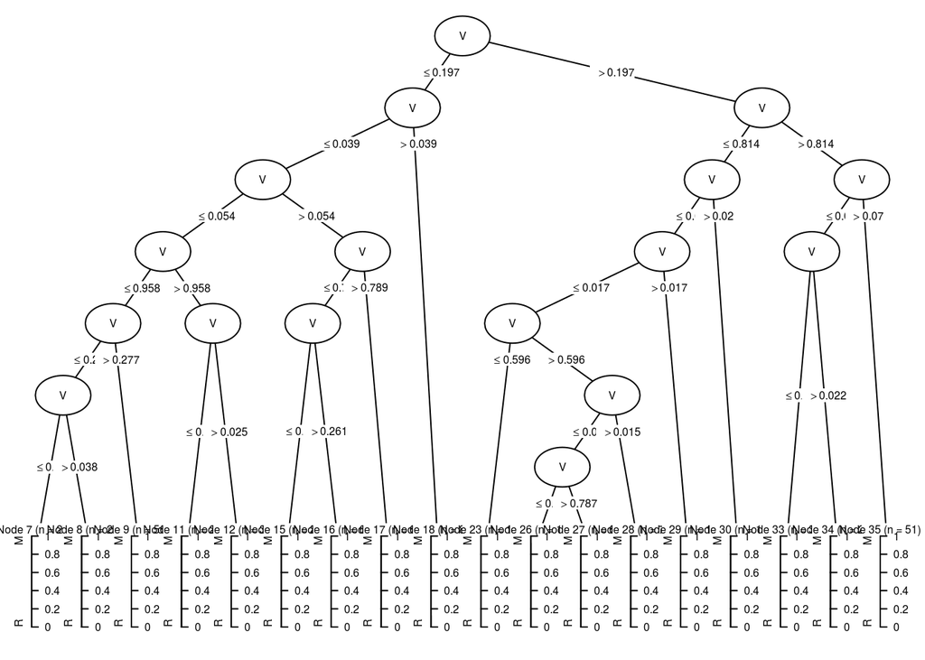

```r
plot(c45_tree_classifier,
     gp = gpar(fontsize = 6),
     inner_panel=node_inner,
     ip_args=list(abbreviate = TRUE, id = FALSE)
)
```

The accuracy of the classifier over the dataset is `98%`, however, the classifier has been trained and tested over the same data so its model is overfitting.

Experimenting with different parameters.

```r
tree_classifier_1 <- J48(Class ~ ., data = sonar, control = Weka_control(U = TRUE))
summary(tree_classifier_1)
```

```
##
## === Summary ===
##
## Correctly Classified Instances         204               98.0769 %
## Incorrectly Classified Instances         4                1.9231 %
## Kappa statistic                          0.9613
## Mean absolute error                      0.0341
## Root mean squared error                  0.1306
## Relative absolute error                  6.854  %
## Root relative squared error             26.1807 %
## Coverage of cases (0.95 level)         100      %
## Mean rel. region size (0.95 level)      59.375  %
## Total Number of Instances              208
##
## === Confusion Matrix ===
##
##    a   b   <-- classified as
##  110   1 |   a = M
##    3  94 |   b = R
```

```r
tree_classifier_2 <- J48(Class ~ ., data = sonar, control = Weka_control(R = TRUE))
summary(tree_classifier_2)
```

```
##
## === Summary ===
##
## Correctly Classified Instances         161               77.4038 %
## Incorrectly Classified Instances        47               22.5962 %
## Kappa statistic                          0.5391
## Mean absolute error                      0.3229
## Root mean squared error                  0.4122
## Relative absolute error                 64.88   %
## Root relative squared error             82.6224 %
## Coverage of cases (0.95 level)          98.5577 %
## Mean rel. region size (0.95 level)      89.9038 %
## Total Number of Instances              208
##
## === Confusion Matrix ===
##
##   a  b   <-- classified as
##  99 12 |  a = M
##  35 62 |  b = R
```

```r
tree_classifier_3 <- J48(Class ~ ., data = sonar, control = Weka_control(C = 0.1))
summary(tree_classifier_3)
```

```
##
## === Summary ===
##
## Correctly Classified Instances         202               97.1154 %
## Incorrectly Classified Instances         6                2.8846 %
## Kappa statistic                          0.9419
## Mean absolute error                      0.0527
## Root mean squared error                  0.1623
## Relative absolute error                 10.5795 %
## Root relative squared error             32.5268 %
## Coverage of cases (0.95 level)          99.0385 %
## Mean rel. region size (0.95 level)      59.375  %
## Total Number of Instances              208
##
## === Confusion Matrix ===
##
##    a   b   <-- classified as
##  110   1 |   a = M
##    5  92 |   b = R
```

```r
tree_classifier_4 <- J48(Class ~ ., data = sonar, control = Weka_control(C = 0.5))
summary(tree_classifier_4)
```

```
##
## === Summary ===
##
## Correctly Classified Instances         204               98.0769 %
## Incorrectly Classified Instances         4                1.9231 %
## Kappa statistic                          0.9613
## Mean absolute error                      0.0341
## Root mean squared error                  0.1306
## Relative absolute error                  6.854  %
## Root relative squared error             26.1807 %
## Coverage of cases (0.95 level)         100      %
## Mean rel. region size (0.95 level)      59.375  %
## Total Number of Instances              208
##
## === Confusion Matrix ===
##
##    a   b   <-- classified as
##  110   1 |   a = M
##    3  94 |   b = R
```

```r
tree_classifier_5 <- J48(Class ~ ., data = sonar, control = Weka_control(O = TRUE))
summary(tree_classifier_5)
```

```
##
## === Summary ===
##
## Correctly Classified Instances         204               98.0769 %
## Incorrectly Classified Instances         4                1.9231 %
## Kappa statistic                          0.9613
## Mean absolute error                      0.0341
## Root mean squared error                  0.1306
## Relative absolute error                  6.854  %
## Root relative squared error             26.1807 %
## Coverage of cases (0.95 level)         100      %
## Mean rel. region size (0.95 level)      59.375  %
## Total Number of Instances              208
##
## === Confusion Matrix ===
##
##    a   b   <-- classified as
##  110   1 |   a = M
##    3  94 |   b = R
```

```r
tree_classifier_6 <- J48(Class ~ ., data = sonar, control = Weka_control(R = TRUE, N = 5))
summary(tree_classifier_6)
```

```
##
## === Summary ===
##
## Correctly Classified Instances         184               88.4615 %
## Incorrectly Classified Instances        24               11.5385 %
## Kappa statistic                          0.7667
## Mean absolute error                      0.1825
## Root mean squared error                  0.3166
## Relative absolute error                 36.6701 %
## Root relative squared error             63.4564 %
## Coverage of cases (0.95 level)          98.0769 %
## Mean rel. region size (0.95 level)      82.4519 %
## Total Number of Instances              208
##
## === Confusion Matrix ===
##
##    a   b   <-- classified as
##  104   7 |   a = M
##   17  80 |   b = R
```

```r
tree_classifier_7 <- J48(Class ~ ., data = sonar, control = Weka_control(R = TRUE, N = 2))
summary(tree_classifier_7)
```

```
##
## === Summary ===
##
## Correctly Classified Instances         161               77.4038 %
## Incorrectly Classified Instances        47               22.5962 %
## Kappa statistic                          0.5409
## Mean absolute error                      0.3191
## Root mean squared error                  0.4217
## Relative absolute error                 64.1125 %
## Root relative squared error             84.532  %
## Coverage of cases (0.95 level)          99.0385 %
## Mean rel. region size (0.95 level)      97.5962 %
## Total Number of Instances              208
##
## === Confusion Matrix ===
##
##   a  b   <-- classified as
##  96 15 |  a = M
##  32 65 |  b = R
```

```r
tree_classifier_8 <- J48(Class ~ ., data = sonar, control = Weka_control(S = TRUE))
summary(tree_classifier_8)
```

```
##
## === Summary ===
##
## Correctly Classified Instances         204               98.0769 %
## Incorrectly Classified Instances         4                1.9231 %
## Kappa statistic                          0.9613
## Mean absolute error                      0.0341
## Root mean squared error                  0.1306
## Relative absolute error                  6.854  %
## Root relative squared error             26.1807 %
## Coverage of cases (0.95 level)         100      %
## Mean rel. region size (0.95 level)      59.375  %
## Total Number of Instances              208
##
## === Confusion Matrix ===
##
##    a   b   <-- classified as
##  110   1 |   a = M
##    3  94 |   b = R
```

```r
tree_classifier_9 <- J48(Class ~ ., data = sonar, control = Weka_control(A = TRUE))
summary(tree_classifier_9)
```

```
##
## === Summary ===
##
## Correctly Classified Instances         204               98.0769 %
## Incorrectly Classified Instances         4                1.9231 %
## Kappa statistic                          0.9613
## Mean absolute error                      0.0901
## Root mean squared error                  0.1551
## Relative absolute error                 18.1028 %
## Root relative squared error             31.0941 %
## Coverage of cases (0.95 level)         100      %
## Mean rel. region size (0.95 level)      74.2788 %
## Total Number of Instances              208
##
## === Confusion Matrix ===
##
##    a   b   <-- classified as
##  110   1 |   a = M
##    3  94 |   b = R
```

```r
# Best result
tree_classifier_10 <- J48(Class ~ ., data = sonar, control = Weka_control(J = TRUE))
summary(tree_classifier_10)
```

```
##
## === Summary ===
##
## Correctly Classified Instances         205               98.5577 %
## Incorrectly Classified Instances         3                1.4423 %
## Kappa statistic                          0.971
## Mean absolute error                      0.0255
## Root mean squared error                  0.1128
## Relative absolute error                  5.1168 %
## Root relative squared error             22.6209 %
## Coverage of cases (0.95 level)         100      %
## Mean rel. region size (0.95 level)      56.4904 %
## Total Number of Instances              208
##
## === Confusion Matrix ===
##
##    a   b   <-- classified as
##  110   1 |   a = M
##    2  95 |   b = R
```

```r
tree_classifier_11 <- J48(Class ~ ., data = sonar, control = Weka_control(doNotMakeSplitPointActualValue = TRUE))
summary(tree_classifier_11)
```

```
##
## === Summary ===
##
## Correctly Classified Instances         204               98.0769 %
## Incorrectly Classified Instances         4                1.9231 %
## Kappa statistic                          0.9613
## Mean absolute error                      0.0341
## Root mean squared error                  0.1306
## Relative absolute error                  6.854  %
## Root relative squared error             26.1807 %
## Coverage of cases (0.95 level)         100      %
## Mean rel. region size (0.95 level)      59.375  %
## Total Number of Instances              208
##
## === Confusion Matrix ===
##
##    a   b   <-- classified as
##  110   1 |   a = M
##    3  94 |   b = R
```

```r
tree_classifier_12 <- J48(Class ~ ., data = sonar, control = Weka_control(J = TRUE, R = TRUE, N = 10))
summary(tree_classifier_12)
```

```
##
## === Summary ===
##
## Correctly Classified Instances         189               90.8654 %
## Incorrectly Classified Instances        19                9.1346 %
## Kappa statistic                          0.8152
## Mean absolute error                      0.1391
## Root mean squared error                  0.2716
## Relative absolute error                 27.9409 %
## Root relative squared error             54.4527 %
## Coverage of cases (0.95 level)          99.5192 %
## Mean rel. region size (0.95 level)      81.0096 %
## Total Number of Instances              208
##
## === Confusion Matrix ===
##
##    a   b   <-- classified as
##  107   4 |   a = M
##   15  82 |   b = R
```

Modifying different parameters has resulted in varying accuracies for the classifiers. The best accuracy results came from classifer 10 in which it doesn’t use MDL correction for info gain on numeric attributes where the accuracy reached `98.5%`.

Adding classification evaluation measures.

```r
findDataStats <- function(labels) {
  possible_values <- unique(labels)
  size <- length(possible_values)

  p_symbol <- possible_values[1]
  n_symbol <- possible_values[2]
  p <- length(which(labels == p_symbol))
  n <- length(which(labels == n_symbol))

  data_stats <- list(
    size = size,
    p_symbol = p_symbol,
    n_symbol = n_symbol,
    p = p,
    n = n
  )
}

findPredictionStats <- function(data_stats, labels, predictions) {
  p_symbol <- data_stats$p_symbol
  n_symbol <- data_stats$n_symbol

  tp <- length(which(predictions == p_symbol & labels == p_symbol))
  fp <- length(which(predictions == p_symbol & labels == n_symbol))
  tn <- length(which(predictions == n_symbol & labels == n_symbol))
  fn <- length(which(predictions == n_symbol & labels == p_symbol))

  prediction_stats <- list(
    tp = tp,
    fp = fp,
    tn = tn,
    fn = fn
  )
  return(prediction_stats)
}

findEvalMeasures <- function(data_stats, prediction_stats) {
  p <- data_stats$p
  n <- data_stats$n

  tp <- prediction_stats$tp
  tn <- prediction_stats$tn
  fp <- prediction_stats$fp
  fn <- prediction_stats$fn

  acc <- (tp + tn) / (p + n)
  err <- (fp + fn) / (p + n)
  rec <- tp / p
  prec <- tp / (tp + fp)
  f <- (2 * prec * rec) / (prec + rec)

  eval_measures <- list(
    accuracy = acc,
    error = err,
    recall = rec,
    precision = prec,
    f_score = f
  )
  return(eval_measures)
}

getStats <- function(classifier, labels, num_folds, seed = NULL) {
  classifier_fold <- evaluate_Weka_classifier(classifier, numFolds = num_folds, seed = seed)

  #print(classifier_fold)
  #print(summary(classifier_fold))

  #print(classifier_fold$details)
  confusionMatrix <- classifier_fold$confusionMatrix

  data_stats <- findDataStats(as.vector(labels))

  pos <- data_stats$p_symbol
  neg <- data_stats$n_symbol

  prediction_stats <- list(
    tp = confusionMatrix[pos, pos],
    fp = confusionMatrix[neg, pos],
    tn = confusionMatrix[neg, neg],
    fn = confusionMatrix[pos, neg]
  )
  eval_measures <- findEvalMeasures(data_stats, prediction_stats)
  eval_measures$mean_error <- classifier_fold$details[["meanAbsoluteError"]]
  return(eval_measures)
}

getAverageStats <- function(stats) {
  acc <- 0
  err <- 0
  rec <- 0
  prec <- 0
  f <- 0
  mean_err <- 0
  for(stat in stats) {
    acc <- acc + stat[["accuracy"]]
    err <- err + stat[["error"]]
    rec <- rec + stat[["recall"]]
    prec <- prec + stat[["precision"]]
    f <- f + stat[["f_score"]]
    mean_err <- mean_err + stat[["mean_error"]]
  }
  n <- length(stats)
  acc <- acc / n
  err <- err / n
  rec <- rec / n
  prec <- prec / n
  f <- f / n
  mean_err <- mean_err / n
  average_stats <- list(
    accuracy = acc,
    error = err,
    recall = rec,
    precision = prec,
    f_score = f,
    mean_error = mean_err
  )
  return(average_stats)
}
```

Calculating evaluation measures to C4.5 decision tree.

```r
predictions <- as.vector(predict(c45_tree_classifier))
labels <- as.vector(sonar$Class)

data_stats <- findDataStats(labels)
prediction_stats <- findPredictionStats(data_stats, labels, predictions)
eval_measures <- findEvalMeasures(data_stats, prediction_stats)
eval_measures
```

```
## $accuracy
## [1] 0.9807692
##
## $error
## [1] 0.01923077
##
## $recall
## [1] 0.9690722
##
## $precision
## [1] 0.9894737
##
## $f_score
## [1] 0.9791667
```

Using 10-fold cross validation for C4.5 decision tree.

```r
c45_tree_func <- function(input_data, num_folds, num_times) {
  stats <- list()
  seed <- 0
  for(i in 1:num_times) {
    seed <- i + 1
    c45_tree_classifier <- J48(Class ~ ., data = input_data)
    stats[[i]] <- getStats(c45_tree_classifier, input_data$Class, num_folds, seed)
  }
  return(getAverageStats(stats))
}

c45_tree_eval_measures <- c45_tree_func(sonar, 10, 1)
c45_tree_eval_measures
```

```
## $accuracy
## [1] 0.7644231
##
## $error
## [1] 0.2355769
##
## $recall
## [1] 0.7525773
##
## $precision
## [1] 0.744898
##
## $f_score
## [1] 0.7487179
##
## $mean_error
## [1] 0.2426871
```

It is evident that using a 10-fold validation produced lower results than using the normal decision tree but this is due to the fact that the normal decision tree has been trained and tested on the same data which results in over-fitting.

**PART 3**

Using other classification algorithms with 10-fold cross validation.

- Random Forest

```r
random_forest_func <- function(input_data, num_folds, num_times) {
  stats <- list()
  seed <- 0
  for(i in 1:num_times) {
    seed <- i + 1
    RandomForest <- make_Weka_classifier("weka/classifiers/trees/RandomForest")
    random_forest_classifier <- RandomForest(Class ~ ., data = input_data)
    stats[[i]] <- getStats(random_forest_classifier, input_data$Class, num_folds, seed)
  }
  return(getAverageStats(stats))
}

rf_eval_measures <- random_forest_func(sonar, 10, 1)
rf_eval_measures
```

```
## $accuracy
## [1] 0.8076923
##
## $error
## [1] 0.1923077
##
## $recall
## [1] 0.742268
##
## $precision
## [1] 0.8275862
##
## $f_score
## [1] 0.7826087
##
## $mean_error
## [1] 0.3243269
```

- Support Vector Machines

```r
svm_func <- function(input_data, num_folds, num_times) {
  stats <- list()
  seed <- 0
  for(i in 1:num_times) {
    seed <- i + 1
    svm_classifier <- SMO(Class ~ ., data = input_data)
    stats[[i]] <- getStats(svm_classifier, input_data$Class, num_folds, seed)
  }
  return(getAverageStats(stats))
}

svm_eval_measures <- svm_func(sonar, 10, 1)
svm_eval_measures
```

```
## $accuracy
## [1] 0.7211538
##
## $error
## [1] 0.2788462
##
## $recall
## [1] 0.6804124
##
## $precision
## [1] 0.7096774
##
## $f_score
## [1] 0.6947368
##
## $mean_error
## [1] 0.2788462
```

- Naive Bayes

```r
naive_bayes_func <- function(input_data, num_folds, num_times) {
  stats <- list()
  seed <- 0
  for(i in 1:num_times) {
    seed <- i + 1
    NaiveBayes <- make_Weka_classifier("weka/classifiers/bayes/NaiveBayes")
    naive_bayes_classifier <- NaiveBayes(Class ~ ., data = input_data)
    stats[[i]] <- getStats(naive_bayes_classifier, input_data$Class, num_folds, seed)
  }
  return(getAverageStats(stats))
}

nb_eval_measures <- naive_bayes_func(sonar, 10, 1)
nb_eval_measures
```

```
## $accuracy
## [1] 0.6682692
##
## $error
## [1] 0.3317308
##
## $recall
## [1] 0.8041237
##
## $precision
## [1] 0.609375
##
## $f_score
## [1] 0.6933333
##
## $mean_error
## [1] 0.3348285
```

- Neural Networks (with 10 epochs)

```r
neural_networks_func <- function(input_data, num_folds, num_times) {
  stats <- list()
  seed <- 0
  for(i in 1:num_times) {
    seed <- i + 1
    NeuralNetworks <- make_Weka_classifier("weka/classifiers/functions/MultilayerPerceptron")
    neural_networks_classifier <- NeuralNetworks(Class ~ ., data = input_data, control = Weka_control(N = 10))
    stats[[i]] <- getStats(neural_networks_classifier, input_data$Class, num_folds, seed)
  }
  return(getAverageStats(stats))
}

nn_eval_measures <- neural_networks_func(sonar, 10, 1)
nn_eval_measures
```

```
## $accuracy
## [1] 0.7596154
##
## $error
## [1] 0.2403846
##
## $recall
## [1] 0.7010309
##
## $precision
## [1] 0.7640449
##
## $f_score
## [1] 0.7311828
##
## $mean_error
## [1] 0.30509
```

- Bagging

```r
bagging_func <- function(input_data, num_folds, num_times) {
  stats <- list()
  seed <- 0
  for(i in 1:num_times) {
    seed <- i + 1
    Bagging <- make_Weka_classifier("weka/classifiers/meta/Bagging")
    bagging_classifier <- Bagging(Class ~ ., data = input_data, control = Weka_control(W = J48))
    stats[[i]] <- getStats(bagging_classifier, input_data$Class, num_folds, seed)
  }
  return(getAverageStats(stats))
}

bagging_eval_measures <- bagging_func(sonar, 10, 1)
bagging_eval_measures
```

```
## $accuracy
## [1] 0.7740385
##
## $error
## [1] 0.2259615
##
## $recall
## [1] 0.7113402
##
## $precision
## [1] 0.7840909
##
## $f_score
## [1] 0.7459459
##
## $mean_error
## [1] 0.3058081
```

- Boosting

```r
boosting_func <- function(input_data, num_folds, num_times) {
  stats <- list()
  seed <- 0
  for(i in 1:num_times) {
    seed <- i + 1
    Boosting <- make_Weka_classifier("weka/classifiers/meta/AdaBoostM1")
    boosting_classifier <- Boosting(Class ~ ., data = input_data, control = Weka_control(W = J48))
    stats[[i]] <- getStats(boosting_classifier, input_data$Class, num_folds, seed)
  }
  return(getAverageStats(stats))
}

boosting_eval_measures <- boosting_func(sonar, 10, 1)
boosting_eval_measures
```

```
## $accuracy
## [1] 0.8413462
##
## $error
## [1] 0.1586538
##
## $recall
## [1] 0.8247423
##
## $precision
## [1] 0.8333333
##
## $f_score
## [1] 0.8290155
##
## $mean_error
## [1] 0.175082
```

Combining all evaluation measures into 1 table.

```r
all_eval_measures <- data.frame(
  Measure=c("accuracy", "mean_error", "recall", "precision", "f_score"),
  C4.5_Decision_Tree=c(c45_tree_eval_measures$accuracy, c45_tree_eval_measures$mean_error, c45_tree_eval_measures$recall, c45_tree_eval_measures$precision, c45_tree_eval_measures$f_score),
  Random_Forest=c(rf_eval_measures$accuracy, rf_eval_measures$mean_error, rf_eval_measures$recall, rf_eval_measures$precision, rf_eval_measures$f_score),
  SVM=c(svm_eval_measures$accuracy, svm_eval_measures$mean_error, svm_eval_measures$recall, svm_eval_measures$precision, svm_eval_measures$f_score),
  Naive_Bayes=c(nb_eval_measures$accuracy, nb_eval_measures$mean_error, nb_eval_measures$recall, nb_eval_measures$precision, nb_eval_measures$f_score),
  Neural_Networks=c(nn_eval_measures$accuracy, nn_eval_measures$mean_error, nn_eval_measures$recall, nn_eval_measures$precision, nn_eval_measures$f_score),
  Bagging=c(bagging_eval_measures$accuracy, bagging_eval_measures$mean_error, bagging_eval_measures$recall, bagging_eval_measures$precision, bagging_eval_measures$f_score),
  Boosting=c(boosting_eval_measures$accuracy, boosting_eval_measures$mean_error, boosting_eval_measures$recall, boosting_eval_measures$precision, boosting_eval_measures$f_score)
)

formattable(all_eval_measures, list())
```

| Measure | C4.5_Decision_Tree | Random_Forest | SVM | Naive_Bayes | Neural_Networks | Bagging | Boosting |
| --- | --- | --- | --- | --- | --- | --- | --- |
| accuracy | 0.7644231 | 0.8076923 | 0.7211538 | 0.6682692 | 0.7596154 | 0.7740385 | 0.8413462 |
| mean_error | 0.2426871 | 0.3243269 | 0.2788462 | 0.3348285 | 0.3050900 | 0.3058081 | 0.1750820 |
| recall | 0.7525773 | 0.7422680 | 0.6804124 | 0.8041237 | 0.7010309 | 0.7113402 | 0.8247423 |
| precision | 0.7448980 | 0.8275862 | 0.7096774 | 0.6093750 | 0.7640449 | 0.7840909 | 0.8333333 |
| f_score | 0.7487179 | 0.7826087 | 0.6947368 | 0.6933333 | 0.7311828 | 0.7459459 | 0.8290155 |

**PART 4**

Importing other datasets.

```r
hepatitis = read.csv("data/hepatitis.data", header=FALSE)
names(hepatitis)[names(hepatitis) == 'V1'] <- 'Class'
hepatitis$Class <- as.factor(hepatitis$Class)

pima = read.csv("data/pima-indians-diabetes.data", header=FALSE)
names(pima)[names(pima) == 'V9'] <- 'Class'
pima$Class <- as.factor(pima$Class)

spect_train = read.csv("data/SPECT.train", header=FALSE)
spect_test = read.csv("data/SPECT.test", header=FALSE)
spect <- rbind(spect_train, spect_test)
names(spect)[names(spect) == 'V1'] <- 'Class'
spect$Class <- as.factor(spect$Class)

spectf_train = read.csv("data/SPECTF.train", header=FALSE)
spectf_test = read.csv("data/SPECTF.test", header=FALSE)
spectf <- rbind(spectf_train, spectf_test)
names(spectf)[names(spectf) == 'V1'] <- 'Class'
spectf$Class <- as.factor(spectf$Class)
```

Testing multiple algorithms on multiple datasets using 10 times 10-fold validation.

```r
sonar_c45_tree_eval_measures <- c45_tree_func(sonar, 10, 10)
sonar_rf_eval_measures <- random_forest_func(sonar, 10, 10)
sonar_svm_eval_measures <- svm_func(sonar, 10, 10)
sonar_nb_eval_measures <- naive_bayes_func(sonar, 10, 10)
sonar_nn_eval_measures <- neural_networks_func(sonar, 10, 10)
sonar_bagging_eval_measures <- bagging_func(sonar, 10, 10)
sonar_boosting_eval_measures <- boosting_func(sonar, 10, 10)

hepatitis_c45_tree_eval_measures <- c45_tree_func(hepatitis, 10, 10)
hepatitis_rf_eval_measures <- random_forest_func(hepatitis, 10, 10)
hepatitis_svm_eval_measures <- svm_func(hepatitis, 10, 10)
hepatitis_nb_eval_measures <- naive_bayes_func(hepatitis, 10, 10)
hepatitis_nn_eval_measures <- neural_networks_func(hepatitis, 10, 10)
hepatitis_bagging_eval_measures <- bagging_func(hepatitis, 10, 10)
hepatitis_boosting_eval_measures <- boosting_func(hepatitis, 10, 10)

pima_c45_tree_eval_measures <- c45_tree_func(pima, 10, 10)
pima_rf_eval_measures <- random_forest_func(pima, 10, 10)
pima_svm_eval_measures <- svm_func(pima, 10, 10)
pima_nb_eval_measures <- naive_bayes_func(pima, 10, 10)
pima_nn_eval_measures <- neural_networks_func(pima, 10, 10)
pima_bagging_eval_measures <- bagging_func(pima, 10, 10)
pima_boosting_eval_measures <- boosting_func(pima, 10, 10)

spect_c45_tree_eval_measures <- c45_tree_func(spect, 10, 10)
spect_rf_eval_measures <- random_forest_func(spect, 10, 10)
spect_svm_eval_measures <- svm_func(spect, 10, 10)
spect_nb_eval_measures <- naive_bayes_func(spect, 10, 10)
spect_nn_eval_measures <- neural_networks_func(spect, 10, 10)
spect_bagging_eval_measures <- bagging_func(spect, 10, 10)
spect_boosting_eval_measures <- boosting_func(spect, 10, 10)

spectf_c45_tree_eval_measures <- c45_tree_func(spectf, 10, 10)
spectf_rf_eval_measures <- random_forest_func(spectf, 10, 10)
spectf_svm_eval_measures <- svm_func(spectf, 10, 10)
spectf_nb_eval_measures <- naive_bayes_func(spectf, 10, 10)
spectf_nn_eval_measures <- neural_networks_func(spectf, 10, 10)
spectf_bagging_eval_measures <- bagging_func(spectf, 10, 10)
spectf_boosting_eval_measures <- boosting_func(spectf, 10, 10)
```

Presenting the results in a table.

```r
getMeasure <- function(measure_name) {
  Measure <- c("Sonar", "Hepatitis", "Pima-Indian Diabetes", "SPECT", "SPECTF")

  C4.5_Decision_Tree <- c(sonar_c45_tree_eval_measures[[measure_name]], hepatitis_c45_tree_eval_measures[[measure_name]], pima_c45_tree_eval_measures[[measure_name]], spect_c45_tree_eval_measures[[measure_name]], spectf_c45_tree_eval_measures[[measure_name]])

  Random_Forest <- c(sonar_rf_eval_measures[[measure_name]], hepatitis_rf_eval_measures[[measure_name]], pima_rf_eval_measures[[measure_name]], spect_rf_eval_measures[[measure_name]], spectf_rf_eval_measures[[measure_name]])

  SVM <- c(sonar_svm_eval_measures[[measure_name]], hepatitis_svm_eval_measures[[measure_name]], pima_svm_eval_measures[[measure_name]], spect_svm_eval_measures[[measure_name]], spectf_svm_eval_measures[[measure_name]])

  Naive_Bayes <- c(sonar_nb_eval_measures[[measure_name]], hepatitis_nb_eval_measures[[measure_name]], pima_nb_eval_measures[[measure_name]], spect_nb_eval_measures[[measure_name]], spectf_nb_eval_measures[[measure_name]])

  Neural_Networks <- c(sonar_nn_eval_measures[[measure_name]], hepatitis_nn_eval_measures[[measure_name]], pima_nn_eval_measures[[measure_name]], spect_nn_eval_measures[[measure_name]], spectf_nn_eval_measures[[measure_name]])

  Bagging <- c(sonar_bagging_eval_measures[[measure_name]], hepatitis_bagging_eval_measures[[measure_name]], pima_bagging_eval_measures[[measure_name]], spect_bagging_eval_measures[[measure_name]], spectf_bagging_eval_measures[[measure_name]])

  Boosting <- c(sonar_boosting_eval_measures[[measure_name]], hepatitis_boosting_eval_measures[[measure_name]], pima_boosting_eval_measures[[measure_name]], spect_boosting_eval_measures[[measure_name]], spectf_boosting_eval_measures[[measure_name]])

  measure <- data.frame(Measure, C4.5_Decision_Tree, Random_Forest, SVM, Naive_Bayes, Neural_Networks, Bagging, Boosting)
  return(measure)
}
```

- Accuracy

```r
accuracy_comparison <- getMeasure("accuracy")
formattable(accuracy_comparison, list())
```

| Measure | C4.5_Decision_Tree | Random_Forest | SVM | Naive_Bayes | Neural_Networks | Bagging | Boosting |
| --- | --- | --- | --- | --- | --- | --- | --- |
| Sonar | 0.7394231 | 0.8418269 | 0.7692308 | 0.6764423 | 0.7822115 | 0.7793269 | 0.7975962 |
| Hepatitis | 0.8322581 | 0.7987097 | 0.8051613 | 0.8245161 | 0.8148387 | 0.8167742 | 0.7412903 |
| Pima-Indian Diabetes | 0.7444010 | 0.7595052 | 0.7673177 | 0.7566406 | 0.7601562 | 0.7483073 | 0.7160156 |
| SPECT | 0.8176030 | 0.8220974 | 0.8389513 | 0.7610487 | 0.8209738 | 0.8307116 | 0.8119850 |
| SPECTF | 0.7599251 | 0.8127341 | 0.7943820 | 0.6820225 | 0.7928839 | 0.8052434 | 0.7921348 |

- Recall

```r
recall_comparison <- getMeasure("recall")
formattable(recall_comparison, list())
```

| Measure | C4.5_Decision_Tree | Random_Forest | SVM | Naive_Bayes | Neural_Networks | Bagging | Boosting |
| --- | --- | --- | --- | --- | --- | --- | --- |
| Sonar | 0.7195876 | 0.7680412 | 0.7381443 | 0.8020619 | 0.7618557 | 0.7103093 | 0.7618557 |
| Hepatitis | 0.9365854 | 0.9894309 | 0.8788618 | 0.8552846 | 0.9040650 | 0.9471545 | 0.8243902 |
| Pima-Indian Diabetes | 0.6007463 | 0.5981343 | 0.5309701 | 0.5996269 | 0.6089552 | 0.5944030 | 0.5705224 |
| SPECT | 0.9066038 | 0.9136792 | 0.9165094 | 0.7632075 | 0.9094340 | 0.9297170 | 0.8910377 |
| SPECTF | 0.8542453 | 0.9504717 | 1.0000000 | 0.6245283 | 0.9877358 | 0.9297170 | 0.8929245 |

- Precision

```r
precision_comparison <- getMeasure("precision")
formattable(precision_comparison, list())
```

| Measure | C4.5_Decision_Tree | Random_Forest | SVM | Naive_Bayes | Neural_Networks | Bagging | Boosting |
| --- | --- | --- | --- | --- | --- | --- | --- |
| Sonar | 0.7220536 | 0.8776189 | 0.7602977 | 0.6179937 | 0.7700295 | 0.7954030 | 0.7962103 |
| Hepatitis | 0.8635644 | 0.8027885 | 0.8760762 | 0.9180469 | 0.8684702 | 0.8419998 | 0.8458929 |
| Pima-Indian Diabetes | 0.6439328 | 0.6756211 | 0.7286284 | 0.6687554 | 0.6745982 | 0.6532728 | 0.5976796 |
| SPECT | 0.8692648 | 0.8690181 | 0.8849571 | 0.9224880 | 0.8710244 | 0.8667892 | 0.8746359 |
| SPECTF | 0.8452742 | 0.8361272 | 0.7943060 | 0.9615286 | 0.7989754 | 0.8416349 | 0.8524365 |

- F Score

```r
f_score_comparison <- getMeasure("f_score")
formattable(f_score_comparison, list())
```

| Measure | C4.5_Decision_Tree | Random_Forest | SVM | Naive_Bayes | Neural_Networks | Bagging | Boosting |
| --- | --- | --- | --- | --- | --- | --- | --- |
| Sonar | 0.7201531 | 0.8190062 | 0.7489448 | 0.6980602 | 0.7650619 | 0.7499645 | 0.7784475 |
| Hepatitis | 0.8985858 | 0.8863794 | 0.8774286 | 0.8855109 | 0.8854513 | 0.8913992 | 0.8348381 |
| Pima-Indian Diabetes | 0.6210290 | 0.6344971 | 0.6142766 | 0.6322985 | 0.6390968 | 0.6223184 | 0.5837530 |
| SPECT | 0.8875196 | 0.8907656 | 0.9003741 | 0.8352904 | 0.8896868 | 0.8971177 | 0.8826962 |
| SPECTF | 0.8496166 | 0.8896267 | 0.8853626 | 0.7571919 | 0.8833505 | 0.8834666 | 0.8720673 |

- Mean Error

```r
mean_error_comparison <- getMeasure("mean_error")
formattable(mean_error_comparison, list())
```

| Measure | C4.5_Decision_Tree | Random_Forest | SVM | Naive_Bayes | Neural_Networks | Bagging | Boosting |
| --- | --- | --- | --- | --- | --- | --- | --- |
| Sonar | 0.2642529 | 0.3083365 | 0.2307692 | 0.3211696 | 0.2790167 | 0.3021478 | 0.2032217 |
| Hepatitis | 0.2646422 | 0.2849684 | 0.1948387 | 0.1750414 | 0.2243965 | 0.2677219 | 0.2649287 |
| Pima-Indian Diabetes | 0.3088172 | 0.3083281 | 0.2326823 | 0.2885125 | 0.3171277 | 0.3049924 | 0.2814514 |
| SPECT | 0.2359519 | 0.2401688 | 0.1610487 | 0.2478154 | 0.2403215 | 0.2368169 | 0.2057869 |
| SPECTF | 0.2451942 | 0.2574457 | 0.2056180 | 0.3159439 | 0.2799713 | 0.2474852 | 0.2072631 |

**Result Interpretation**

After looking on all the previous tables in which they contain the algorithms’ performance results over all datasets for each performance measure, it is noticed that every algorithm performance measure vary depending on the dataset used which is acceptable due to the different nature of the datasets used and of course for the different nature of the algorithm itself. So, to compare the overall performance of each algorithm, it is needed to have a more conclusive generalized measure which can be interpreted into a more meaningful result and that moves the report to the next section which is testing.

Performing student’s paired T test.

```r
hashMatch <- function(x, y) {
  laply(y, function(z) {
    x[[z]]
  })
}

getMeasureCombinations <- function(measure_comparison, alt) {
  modified_comparison <- subset(measure_comparison, select = -c(Measure))
  measure_combinations <- combn(names(modified_comparison), 2, simplify=FALSE)

  algo_cnt <- hash(names(modified_comparison), 0)

  for(measure_combination in measure_combinations) {
    measure_data <- data.frame(measure_comparison$Measure)
    measure_data <- cbind(measure_data, measure_comparison[[measure_combination[1]]])
    measure_data <- cbind(measure_data, measure_comparison[[measure_combination[2]]])

    colnames(measure_data) <- c("Measure", measure_combination[1], measure_combination[2])
    #print(measure_data)

    test_result <- t.test(measure_data[[measure_combination[1]]], measure_data[[measure_combination[2]]], paired = TRUE, alt = alt)
    #print(test_result)

    if(test_result$p.value < 0.05) {
      algo_cnt[[measure_combination[1]]] <- algo_cnt[[measure_combination[1]]] + 1
    } else {
      algo_cnt[[measure_combination[2]]] <- algo_cnt[[measure_combination[2]]] + 1
    }
  }

  algo_frame <- data.frame(names(modified_comparison))
  algo_cnt_frame <- hashMatch(algo_cnt, names(modified_comparison))
  algo_frame <- cbind(algo_frame, algo_cnt_frame)
  colnames(algo_frame) <- c("Algorithm", "Win Count")
  return(algo_frame)
}
```

Performing test on:

- Accuracy

```r
accuracy_frame <- getMeasureCombinations(accuracy_comparison, "greater")
formattable(accuracy_frame, list())
```

| Algorithm | Win Count |
| --- | --- |
| C4.5_Decision_Tree | 1 |
| Random_Forest | 2 |
| SVM | 3 |
| Naive_Bayes | 1 |
| Neural_Networks | 4 |
| Bagging | 5 |
| Boosting | 5 |

- Recall

```r
recall_frame <- getMeasureCombinations(recall_comparison, "greater")
formattable(recall_frame, list())
```

| Algorithm | Win Count |
| --- | --- |
| C4.5_Decision_Tree | 0 |
| Random_Forest | 1 |
| SVM | 2 |
| Naive_Bayes | 3 |
| Neural_Networks | 5 |
| Bagging | 5 |
| Boosting | 5 |

- Precision

```r
precision_frame <- getMeasureCombinations(precision_comparison, "greater")
formattable(precision_frame, list())
```

| Algorithm | Win Count |
| --- | --- |
| C4.5_Decision_Tree | 0 |
| Random_Forest | 1 |
| SVM | 2 |
| Naive_Bayes | 3 |
| Neural_Networks | 4 |
| Bagging | 5 |
| Boosting | 6 |

- F Score

```r
f_score_frame <- getMeasureCombinations(f_score_comparison, "greater")
formattable(f_score_frame, list())
```

| Algorithm | Win Count |
| --- | --- |
| C4.5_Decision_Tree | 0 |
| Random_Forest | 3 |
| SVM | 2 |
| Naive_Bayes | 2 |
| Neural_Networks | 4 |
| Bagging | 5 |
| Boosting | 5 |

- Mean Error

```r
mean_error_frame <- getMeasureCombinations(mean_error_comparison, "less")
formattable(mean_error_frame, list())
```

| Algorithm | Win Count |
| --- | --- |
| C4.5_Decision_Tree | 0 |
| Random_Forest | 1 |
| SVM | 5 |
| Naive_Bayes | 2 |
| Neural_Networks | 3 |
| Bagging | 4 |
| Boosting | 6 |

**Result Interpretation**